# Group Assignment of Web & Social Media (Shark Tank Companies.csv)

Divya Thomas,Neha Tiwary, Saurav Suman, Anurag Kedia, Peehu (Group 8)

## Problem Statement -

Group Assignment: Business Intelligence Using Text Mining

1. A dataset of Shark Tank episodes is made available. It contains 495 entrepreneurs making their pitch to the VC sharks.
2. You will ONLY use “Description” column for the initial text mining exercise.
3. Step 1:
1. Extract the text into text corpus and perform following operations:
2. Create DTM
2. Use “Deal” as a Dependent Variable
3. Use CART model and arrive at your CART diagram
4. Build Logistic Regression Model and find out your accuracy of the model
5. Build randomForst model and arrive at your varImpPlot
4. Step 2:
1. Now, add a variable to you analysis called as “ratio”. This variable is “askedfor/valuation”. (This variable is to be added as a column to your dataframe in Step 1.)
2. Rebuild “New” models- CART, randomForest and Logistic Regression
5. Deliverables: (in a word document)
1. CART Tree (Before and After) (5 Marks)
2. RandomForest plot (Before and After) (5 Marks)
3. Confusion Matrix of Logistic Regression (Before and After) (5 Marks)
4. (Most important)- Your interpretation in plain simple English not extending more than half a page. (15 Marks)

## Solution -

#### Read the CSV file

```r
shark= read.csv(file = file.choose(), stringsAsFactors=FALSE)
table(shark$deal)
```

```
FALSE  TRUE
  244   251
```

#### Load the Libraries required for TEXT Analysis

```r
library(tm)
library(SnowballC)
library(wordcloud)
```

After loading the dataset, we need to change the dataset into a corpus(bag of words) with a variable name discription. After that few basic steps are required for the cleaning process and normalising the data. Those steps are mentioned below

#### Building the Corpus

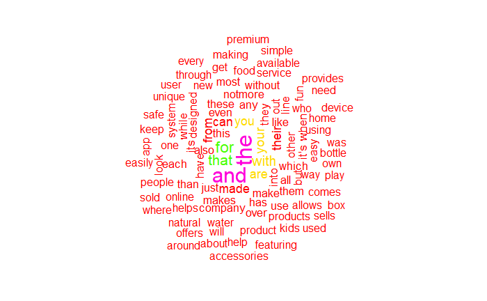

```r
# Create corpus
corpus_shark = Corpus(VectorSource(shark$description))

# Word Cloud for Corpus
wordcloud(corpus_shark,colors=rainbow(7),max.words=100,scale=c(2, 1), random.order=FALSE, rot.per=0.25)
```

```r
# Convert to lower-case
corpus_shark = tm_map(corpus_shark, tolower)
```

```
transformation drops documents
```

```r
# Remove punctuation
corpus_shark = tm_map(corpus_shark, removePunctuation)
```

```
transformation drops documents
```

Here, we have not not dropped the stop words. So we can see words like “and”, “the”, “their” etc in the word cloud. We are removing the stop words from the document in further steps

#### Word cloud after removing stop words

```r
# Remove stopwords, the, and
corpus_shark = tm_map(corpus_shark, removeWords, c("the", "and", stopwords("english")))
```

```
transformation drops documents
```

```r
# Remove extra whitespaces if any
corpus_shark = tm_map(corpus_shark, stripWhitespace)
```

```
transformation drops documents
```

```r
# Stem document
corpus_shark = tm_map(corpus_shark, stemDocument)
```

```
transformation drops documents
```

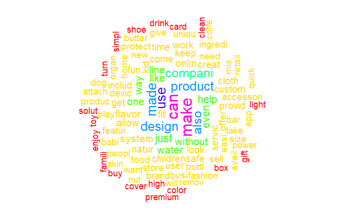

```r
# Word cloud after removing stopwords and cleaning
wordcloud(corpus_shark,colors=rainbow(7),max.words=100,scale=c(2, 1), random.order=FALSE, rot.per=0.25)
```

For further analysis of text, we have to use DTM(Document-Term Matrix). In text mining, it is important to create the document-term matrix (DTM) of the corpus we are interested in. A DTM is basically a matrix, with documents designated by rows and words by columns, that the elements are the counts or the weights (usually by tf-idf). Subsequent analysis is usually based creatively on DTM. This will help us identify unique words in the corpus used frequently.

#### Create the Document Term Matrix (DTM)

```r
shark.frequencies = DocumentTermMatrix(corpus_shark)
shark.frequencies
```

```
<<DocumentTermMatrix (documents: 495, terms: 3501)>>
Non-/sparse entries: 9531/1723464
Sparsity           : 99%
Maximal term length: 21
Weighting          : term frequency (tf)
```

#### Remove the sparse terms

```r
sparse_shark = removeSparseTerms(shark.frequencies, 0.995)
```

#### Build the DataFrame of the DTM

```r
# Convert to a data frame
shark_sparse = as.data.frame(as.matrix(sparse_shark))

# Make all variable names R-friendly
colnames(shark_sparse) = make.names(colnames(shark_sparse))

# Add dependent variable
shark_sparse$deal = shark$deal

#Total number of deal
table(shark_sparse$deal)
```

```
FALSE  TRUE
  244   251
```

## Model Building

We will use 3 different models and check its accuracy n performance as per the question to predict whether investors will invest in the businesses or not. Deal will be the dependant variable.

#### Build CART Model

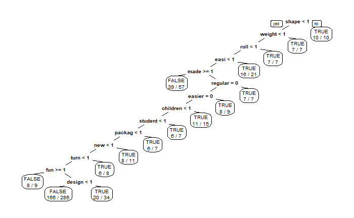

```r
# Load the Libraries
library(rpart)
library(rpart.plot)

shark_CART = rpart(deal ~ ., data=shark_sparse, method="class")

#CART Diagram
prp(shark_CART, extra=2)
```

#### Predict and Evaluate the Performance of CART

```r
Predict_CART = predict(shark_CART, data=shark_sparse, type="class")

CART_initial <- table(shark_sparse$deal, Predict_CART)

# Baseline accuracy
BaseAcc_CART = sum(diag(CART_initial))/sum(CART_initial)
BaseAcc_CART
```

```
[1] 0.6565657
```

#### Build Random Forest Model

```r
# Load Library
library(randomForest)

set.seed(123)

shark_RF = randomForest(deal ~ ., data=shark_sparse)
```

```
The response has five or fewer unique values.  Are you sure you want to do regression?
```

```r
shark_RF
```

```
Call:
 randomForest(formula = deal ~ ., data = shark_sparse)
               Type of random forest: regression
                     Number of trees: 500
No. of variables tried at each split: 300

          Mean of squared residuals: 0.2677842
                    % Var explained: -7.14
```

#### Predict and Evaluate the Performance of Random Forest

```r
# Make predictions:
Predict_RF = predict(shark_RF, data=shark_sparse)

# Evaluate the performance:
RF_Initial <- table(shark_sparse$deal, Predict_RF>0.5)

# Baseline accuracy:
BaseAcc_RF = sum(diag(RF_Initial))/sum(RF_Initial)
BaseAcc_RF
```

```
[1] 0.5535354
```

#### Variable Importance of Random Forest

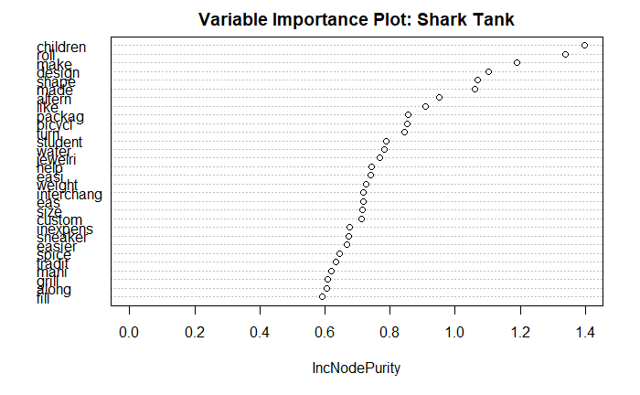

```r
#Variable importance:
varImpPlot(shark_RF,main='Variable Importance Plot: Shark Tank',type=2)
```

We observer from the above varibale Importance plot that children,roll,make,design,shape,made,altern,like,packages are the top variables which are important and significant for the deal and model building.

#### Build Logistic Regression Model

```r
set.seed(123)

shark_logistic = glm(deal~., data = shark_sparse)
```

#### Predict and Evaluate the performance of Logistic Model

```r
# Make predictions:
Pred_Logistic = predict(shark_logistic, data=shark_sparse)

# Evaluate the performance:
Logistic_Initial <- table(shark_sparse$deal, Pred_Logistic>0.5)

# Baseline accuracy:
BaseAcc_Logistic = sum(diag(Logistic_Initial))/sum(Logistic_Initial)
BaseAcc_Logistic
```

```
[1] 0.9979798
```

As per the question, we have to now add a variable called as Ratio which will be derived using column askfor/valuation and then we have to run the models again to see after effect to check if the accuracy have improved in the models.

#### Adding an additional variable called as Ratio to the DTM which will be derived using column askfor/valuation

```r
# Addition of Ratio variable into shark_sparse
shark_sparse$ratio = shark$askedFor/shark$valuation
```

Now, we have to re-run the model to check if any changes happen in the accuracy n performance

#### CART with Ratio Column

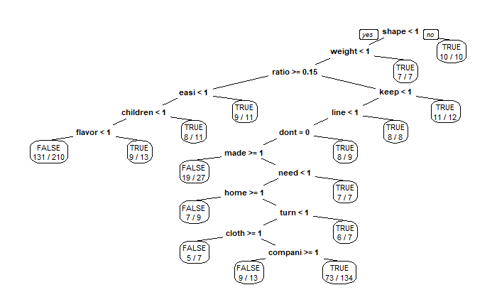

```r
#CART Model
shark_CART2 = rpart(deal ~ ., data=shark_sparse, method="class")

#CART Diagram
prp(shark_CART2, extra=2)
```

#### Predict and Evaluate the CART model using Ratio column

```r
# Evaluate the performance:
pred_CART_After = predict(shark_CART2, data=shark_sparse, type="class")

CART_After <- table(shark_sparse$deal, pred_CART_After)

# Baseline accuracy:
BaseAcc_CART2 = sum(diag(CART_After))/sum(CART_After)
BaseAcc_CART2
```

```
[1] 0.6606061
```

#### Build Random Forest with Ratio Column

```r
# Random Forest Model
shark_RF2 = randomForest(deal ~ ., data=shark_sparse)
```

```
The response has five or fewer unique values.  Are you sure you want to do regression?
```

```r
shark_RF2
```

```
Call:
 randomForest(formula = deal ~ ., data = shark_sparse)
               Type of random forest: regression
                     Number of trees: 500
No. of variables tried at each split: 300

          Mean of squared residuals: 0.262773
                    % Var explained: -5.13
```

#### Predict and Evaluate the RF model using Ratio column

```r
# Evaluate the performance:
pred_RF_After = predict(shark_RF2, data=shark_sparse, type="class")

RF_After <- table(shark_sparse$deal, pred_RF_After>0.5)

# Baseline accuracy:
BaseAcc_RF2 = sum(diag(RF_After))/sum(RF_After)
BaseAcc_RF2
```

```
[1] 0.5575758
```

#### Variable Importance of Random Forest

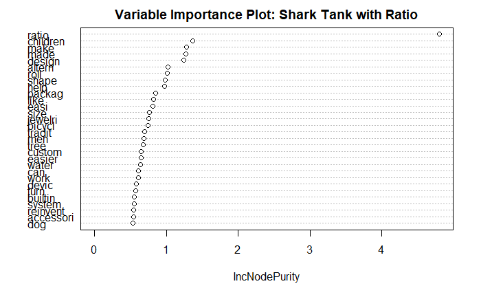

```r
varImpPlot(shark_RF2,main='Variable Importance Plot: Shark Tank with Ratio',type=2)
```

We observer that along with previously mentioned important variables , ratio has become the most important variable for a deal and model building.

#### Logistic Regression with Ratio Column

```r
#Logistic Model
shark_logit2 = glm(deal~., data = shark_sparse)
```

#### Predict using Logistic Regression model

```r
# Make predictions:
pred_Logit_After = predict(shark_logit2, data=shark_sparse)

# Evaluate the performance of the Random Forest
Logit_After <- table(shark_sparse$deal, pred_Logit_After>= 0.5)

# Baseline accuracy
BaseAcc_Logit2 = sum(diag(Logit_After))/sum(Logit_After)
BaseAcc_Logit2
```

```
[1] 1
```

### Comparing all the 3 model with their performance - CART, Random Forest and Logistic regression

```r
df_fin =rbind(BaseAcc_CART,BaseAcc_CART2, BaseAcc_RF,BaseAcc_RF2,BaseAcc_Logistic, BaseAcc_Logit2)
row.names(df_fin) = c('CART Accuracy', 'CART_Ratio Accuracy','RF Accuracy', 'RF_Ratio Accuracy','Logit Accuracy', 'Logit_Ratio Accuracy')

#install.packages("kableExtra")
library(kableExtra)
print("Model Performance Comparison Metrics without splitting the data into train and test")
```

```
[1] "Model Performance Comparison Metrics without splitting the data into train and test"
```

```r
kable(round(df_fin,3)) %>%
  kable_styling(c("striped","bordered"))
```

| CART Accuracy | 0.657 |
| --- | --- |
| CART_Ratio Accuracy | 0.661 |
| RF Accuracy | 0.554 |
| RF_Ratio Accuracy | 0.558 |
| Logit Accuracy | 0.998 |
| Logit_Ratio Accuracy | 1.000 |

```r
NA
```

#### Checking the same data after splitting, if some difference comes in accuracy

```r
shark_sparse$ratio= NULL
```

## BUILDING THE MODEL WITH SPLITTING THE DATA INTO TRAIN AND TEST SET:

#### Split the data into Train and Test with having deal variable

```r
library(caTools)

#set.seed(144)

spl = sample.split(shark_sparse$deal, SplitRatio = 0.7)

train = subset(shark_sparse, spl == TRUE)
test = subset(shark_sparse, spl == FALSE)

prop.table(table(train$deal))
```

```
    FALSE      TRUE
0.4927954 0.5072046
```

```r
prop.table(table(test$deal))
```

```
    FALSE      TRUE
0.4932432 0.5067568
```

#### Build CART Model

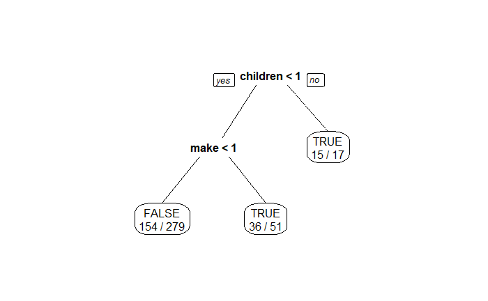

```r
# Load the Libraries
library(rpart)
library(rpart.plot)

shark_CART = rpart(deal ~ ., data=train, method="class")

#CART Diagram
prp(shark_CART, extra=2)
```

#### Predict and Evaluate the Performance of CART

```r
Predict_CART = predict(shark_CART, newdata=test, type="class")

CART_initial <- table(test$deal, Predict_CART)

# Baseline accuracy
BaseAcc_CART = sum(diag(CART_initial))/sum(CART_initial)
BaseAcc_CART
```

```
[1] 0.5067568
```

#### Build Random Forest Model

```r
# Load Library
library(randomForest)

set.seed(123)

shark_RF = randomForest(deal ~ ., data=train)
```

```
The response has five or fewer unique values.  Are you sure you want to do regression?
```

```r
shark_RF
```

```
Call:
 randomForest(formula = deal ~ ., data = train)
               Type of random forest: regression
                     Number of trees: 500
No. of variables tried at each split: 300

          Mean of squared residuals: 0.2692468
                    % Var explained: -7.72
```

#### Predict and Evaluate the Performance of Random Forest

```r
# Make predictions:
Predict_RF = predict(shark_RF, newdata=test)

# Evaluate the performance:
RF_Initial <- table(test$deal, Predict_RF>0.5)

# Baseline accuracy:
BaseAcc_RF = sum(diag(RF_Initial))/sum(RF_Initial)
BaseAcc_RF
```

```
[1] 0.5675676
```

#### Variable Importance of Random Forest

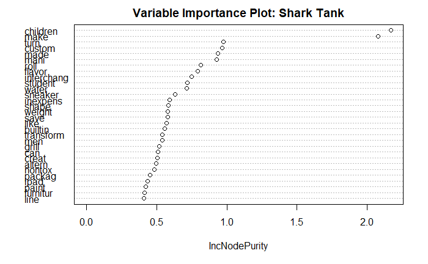

```r
#Variable importance:
varImpPlot(shark_RF,main='Variable Importance Plot: Shark Tank',type=2)
```

#### Build Logistic Regression Model

```r
set.seed(123)

shark_logistic = glm(deal~., data = train)
```

#### Predict and Evaluate the performance of Logistic Model

```r
# Make predictions:
Pred_Logistic = predict(shark_logistic, newdata=test)
```

```
prediction from a rank-deficient fit may be misleading
```

```r
# Evaluate the performance:
Logistic_Initial <- table(test$deal, Pred_Logistic>0.5)

# Baseline accuracy:
BaseAcc_Logistic = sum(diag(Logistic_Initial))/sum(Logistic_Initial)
BaseAcc_Logistic
```

```
[1] 0.5337838
```

#### Adding an additional variable called as Ratio to the DTM which will be derived using column askfor/valuation

```r
# Addition of Ratio variable into shark_sparse
shark_sparse$ratio = shark$askedFor/shark$valuation
```

#### Split the data into Train and Test with having deal and ratio variables

```r
library(caTools)

#set.seed(144)

spl = sample.split(shark_sparse$deal, SplitRatio = 0.7)

train = subset(shark_sparse, spl == TRUE)
test = subset(shark_sparse, spl == FALSE)

prop.table(table(train$deal))
```

```
    FALSE      TRUE
0.4927954 0.5072046
```

```r
prop.table(table(test$deal))
```

```
    FALSE      TRUE
0.4932432 0.5067568
```

#### CART with Ratio Column

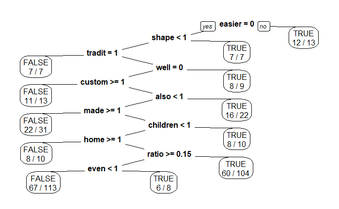

```r
#CART Model
shark_CART2 = rpart(deal ~ ., data=train, method="class")

#CART Diagram
prp(shark_CART2, extra=2)
```

#### Predict and Evaluate the CART model using Ratio column

```r
# Evaluate the performance:
pred_CART_After = predict(shark_CART2, newdata=test, type="class")

CART_After <- table(test$deal, pred_CART_After)

# Baseline accuracy:
BaseAcc_CART2 = sum(diag(CART_After))/sum(CART_After)
BaseAcc_CART2
```

```
[1] 0.6013514
```

#### Build Random Forest with Ratio Column

```r
# Random Forest Model
shark_RF2 = randomForest(deal ~ ., data=train)
```

```
The response has five or fewer unique values.  Are you sure you want to do regression?
```

```r
shark_RF2
```

```
Call:
 randomForest(formula = deal ~ ., data = train)
               Type of random forest: regression
                     Number of trees: 500
No. of variables tried at each split: 300

          Mean of squared residuals: 0.2716559
                    % Var explained: -8.68
```

#### Predict and Evaluate the RF model using Ratio column

```r
# Evaluate the performance:
pred_RF_After = predict(shark_RF2, newdata=test, type="class")

RF_After <- table(test$deal, pred_RF_After>0.3)

# Baseline accuracy:
BaseAcc_RF2 = sum(diag(RF_After))/sum(RF_After)
BaseAcc_RF2
```

```
[1] 0.6351351
```

#### Variable Importance of Random Forest

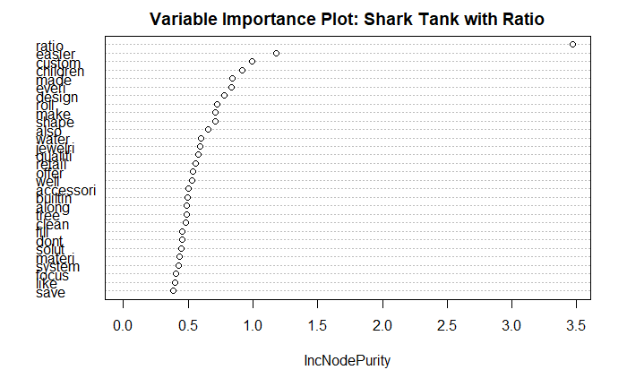

```r
varImpPlot(shark_RF2,main='Variable Importance Plot: Shark Tank with Ratio',type=2)
```

#### Logistic Regression with Ratio Column

```r
#Logistic Model
shark_logit2 = glm(deal~., data = train)
```

#### Predict using the Logistic Regression Model

```r
# Make predictions:
pred_Logit_After = predict(shark_logit2, newdata=test)
```

```
prediction from a rank-deficient fit may be misleading
```

```r
# Evaluate the performance of the Random Forest
Logit_After <- table(test$deal, pred_Logit_After>= 0.3)

# Baseline accuracy
BaseAcc_Logit2 = sum(diag(Logit_After))/sum(Logit_After)
BaseAcc_Logit2
```

```
[1] 0.5202703
```

### Comparing all the 3 model with their performance - CART, Random Forest and Logistic regression

```r
df_fin =rbind(BaseAcc_CART,BaseAcc_CART2, BaseAcc_RF,BaseAcc_RF2,BaseAcc_Logistic, BaseAcc_Logit2)
row.names(df_fin) = c('CART Accuracy', 'CART_Ratio Accuracy','RF Accuracy', 'RF_Ratio Accuracy','Logit Accuracy', 'Logit_Ratio Accuracy')

#install.packages("kableExtra")
library(kableExtra)
print("Model Performance Comparison Metrics with splitting the data into train and test")
```

```
[1] "Model Performance Comparison Metrics with splitting the data into train and test"
```

```r
kable(round(df_fin,3)) %>%
  kable_styling(c("striped","bordered"))
```

| CART Accuracy | 0.507 |
| --- | --- |
| CART_Ratio Accuracy | 0.601 |
| RF Accuracy | 0.568 |
| RF_Ratio Accuracy | 0.635 |
| Logit Accuracy | 0.534 |
| Logit_Ratio Accuracy | 0.520 |

## Conclusion:

- We built various models like CART, RF and logistic on the text mining dataset with and without split

### Without Split:

We begin by model building on the whole dataset.The observations are as below:

1. With CART Model we were able to predict around 65.7% and 66.1% accurate results using only description(Before) and description with ratio(After) respectively.
2. Using Random Forest, we were able to predict 55.4% and 55.8% accurate results using only description(Before) and description with ratio (After) respectively.
3. With Logistic regression, we were able to predict 99.8% and 100% accurate results with both parameters using only description(Before) and description with ratio (After)respectively.

However,since we have not performed the train and test split ,the results might be because of overfitting

### With Split:

Observations after data splitting:

1. With CART Model we were able to predict around 50.7% and 60.1% accurate results using only description(Before) and description with ratio(After)respectively.
2. Using Random Forest, we were able to predict 56.8% and 63.5% accurate results using only description(Before) and description with ratio(After) respectively.
3. With Logistic regression, we were able to predict 53.4% and 52% accurate results with both parameters using only description(Before) and description with ratio(After) respectively.
- Observation 1:

- Observation 2:

After the addition of the ratio variable we could see that the accuracy of model has increased with the data which is not splitted and also with the splitted data we could see that the accuracy has increased manily in CART and RF models , indicating the feature engineering has increased the performance of the model.

- Observation 3 (Variable Importance):

The “make”, “design” and “shape” are some keywords associated with successful deals.This indicates tangible product deals.

Products related to children, water , packages are the most sought after, for the deals to take place.

ratio is one the imporatant factor for a deal.

Using these insights, the entrepreneurs can customize their start-up’s description to get a better deal rate.

- NOTE

With splitted data, further introduction of the combinations of parameters , tuning of hyper parameters , validation with significant variables and removing unnecessary variables etc may help us to achieve higher accuracy.